# seaborn code base

```python
import pandas as pd
import seaborn as sns
sns.set()
%matplotlib inline
```

```python
# snsで使えるデータ一覧
sns.get_dataset_names()
```

```
['anscombe',
 'attention',
 'brain_networks',
 'car_crashes',
 'diamonds',
 'dots',
 'exercise',
 'flights',
 'fmri',
 'gammas',
 'iris',
 'mpg',
 'planets',
 'tips',
 'titanic']
```

```python
iris = sns.load_dataset("iris")
# irisを読み込み
titanic = sns.load_dataset("titanic")
#titanicを読み込み
```

```python
iris.head()
```

|  | sepal_length | sepal_width | petal_length | petal_width | species |
| --- | --- | --- | --- | --- | --- |
| 0 | 5.1 | 3.5 | 1.4 | 0.2 | setosa |
| 1 | 4.9 | 3.0 | 1.4 | 0.2 | setosa |
| 2 | 4.7 | 3.2 | 1.3 | 0.2 | setosa |
| 3 | 4.6 | 3.1 | 1.5 | 0.2 | setosa |
| 4 | 5.0 | 3.6 | 1.4 | 0.2 | setosa |

```python
iris.describe()
```

|  | sepal_length | sepal_width | petal_length | petal_width |
| --- | --- | --- | --- | --- |
| count | 150.000000 | 150.000000 | 150.000000 | 150.000000 |
| mean | 5.843333 | 3.057333 | 3.758000 | 1.199333 |
| std | 0.828066 | 0.435866 | 1.765298 | 0.762238 |
| min | 4.300000 | 2.000000 | 1.000000 | 0.100000 |
| 25% | 5.100000 | 2.800000 | 1.600000 | 0.300000 |
| 50% | 5.800000 | 3.000000 | 4.350000 | 1.300000 |
| 75% | 6.400000 | 3.300000 | 5.100000 | 1.800000 |
| max | 7.900000 | 4.400000 | 6.900000 | 2.500000 |

# ヒストグラム

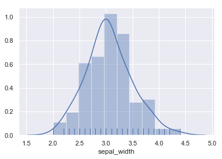

```python
sns.distplot(iris.sepal_width,kde=True, rug=True, bins=10, vertical=False, color='b')
```

ここでデータ以外の引数として以下のものを渡せます。

- kde: ガウスのカーネル密度推定をプロットするか
- rug: サポート軸にラグプロット（データ出現点）を描くかどうか
- bins: ビンの数
- vertical: 分布を縦軸にプロットするか

またここで種別ごとにプロットするさせたい場合は以下のように書きます。

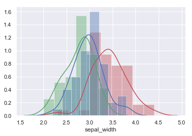

```python
sns.distplot(iris[iris["species"] == "setosa"].sepal_width,color='r')
sns.distplot(iris[iris["species"] == "versicolor"].sepal_width,color='g')
sns.distplot(iris[iris["species"] == "virginica"].sepal_width,color='b')
```

# 散布図

縦軸、横軸に2つの数値変数を取ったグラフで、2変数間の関係を可視化したもの

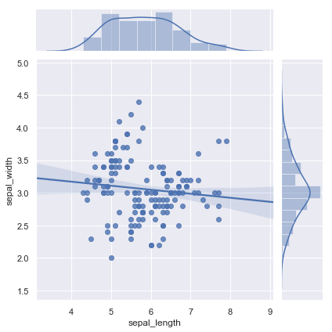

```python
sns.jointplot(x='sepal_length',y='sepal_width',data=iris, kind='reg')
```

またkindには以下のように様々なものを渡すことができます

- reg: 回帰直線を引く
- hex: 六角形で表示
- kde: 等高線で密度表示
- resid: 回帰直線からの残差を出力

色々と試してみてください。

# 散布図行列

Seabornには便利なものがありこの散布図をすべての数値変数同士で簡単に描けるものがあります。 ここでhueを設定することによってカテゴリ別に見ることができます。

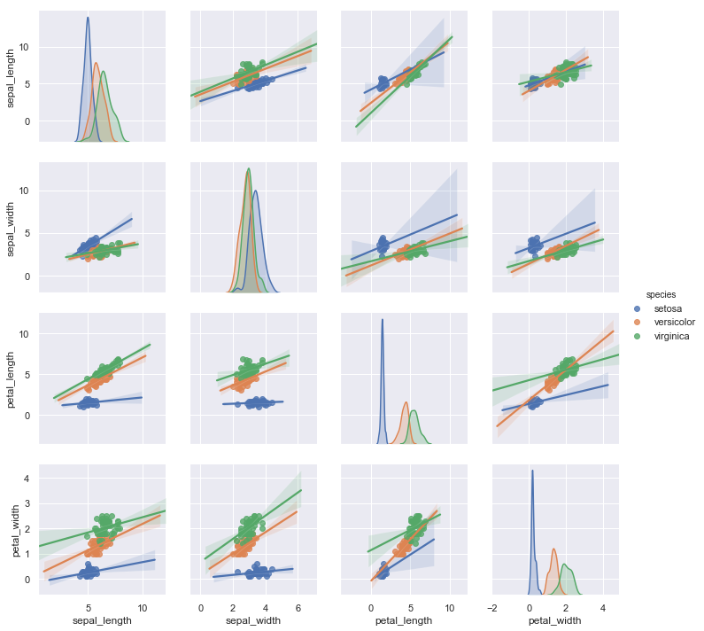

```python
sns.pairplot(iris, hue='species',diag_kind='kde',kind='reg')
```

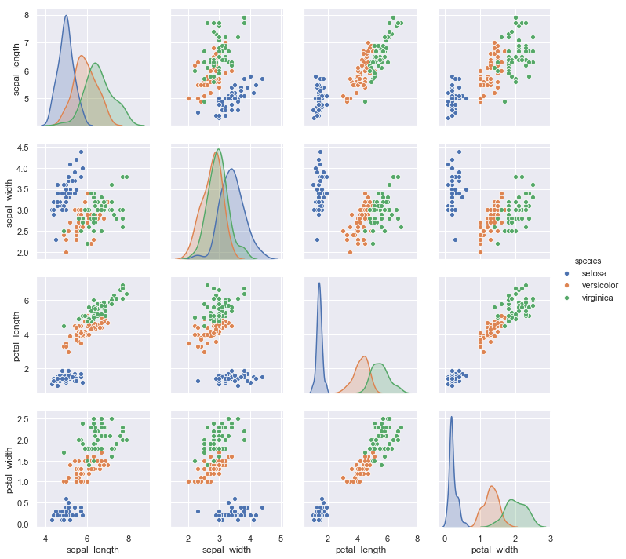

```python
sns.pairplot(iris, hue='species',diag_kind='kde')
```

# ヒートマップ

このヒートマップというのは行列形式で渡されたデータの強弱を色を用いて可視化するものです。例として2つ見ていきましょう。

相関行列 まず相関行列というものはどういうものなのかというと、数値変数間の相関係数を並べたものであり、これは対称行列となります。

実際にirisのデータで見ていきましょう。

相関係数を求める 相関係数は共分散を二変数の標準偏差で割れば良いのですが pandas を使うと関数ひとつで簡単に求まります。

```python
corr = iris.corr()
corr
```

|  | sepal_length | sepal_width | petal_length | petal_width |
| --- | --- | --- | --- | --- |
| sepal_length | 1.000000 | -0.117570 | 0.871754 | 0.817941 |
| sepal_width | -0.117570 | 1.000000 | -0.428440 | -0.366126 |
| petal_length | 0.871754 | -0.428440 | 1.000000 | 0.962865 |
| petal_width | 0.817941 | -0.366126 | 0.962865 | 1.000000 |

このようなものが出るかと思いますが、これをヒートマップに起こすとこんな感じになります。 ここでの引数は

- annot: 数値を表示するかどうか
- cbar: カラーバーを表示するかどうか
- square: 正方形で表示するかどうか

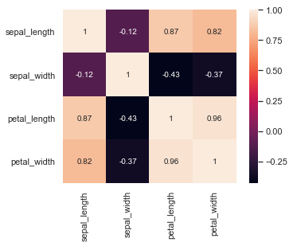

```python
sns.heatmap(iris.corr(), annot=True, cbar=True, square=True)
```

# クラスターマップ

続いてクラスターマップについてですが数値変数ごとに階層的クラスタリングを行い、デンドログラムとともに近いクラスターを持つ変数が近くになるように色の濃淡でデータの密度や値の分布を可視化したものです。

クラスター分析については以下のサイトを参考にしてみてください。 https://www.macromill.com/service/data_analysis/cluster-analysis.html

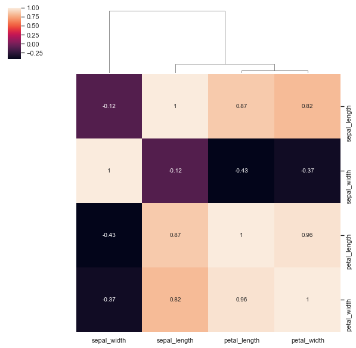

```python
sns.clustermap(corr,annot=True,col_cluster=True, row_cluster=False)
```

相関行列を入れたので先ほどと色の濃淡は同じですが、新たにデンドログラムが表示されます。また引数として先ほどのannotに加えて列、行にデンドログラムを表示するかどうかを与えるcol_cluster,row_clusterがあります。

# 箱ひげ図

これはデータのばらつきをわかりやすく可視化したものになります。

見方としては

- 箱の中央の線：データの中央値
- 箱の下側の線：第一四分位数(1Q)
- 箱の上側の線：第三四分位数(3Q)
- 一番上の線：データの最大値
- 一番下の線：データの最小値
- 箱ひげ図外の点：外れ値（1Q-(IQR×1.5)~3Q+(IQR×1.5)に収まっていないもの） (IQR: 3Q-1Q)

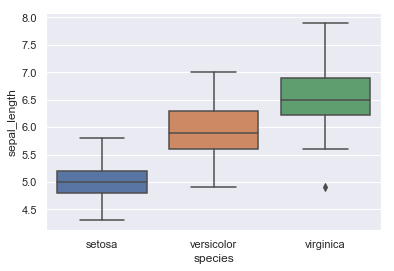

```python
sns.boxplot(x='species',y='sepal_length',data=iris)
```

# 棒グラフ

Barplot これはデータの平均値を高さとして描画したものです。

ここからはタイタニックのデータを使っていきます。

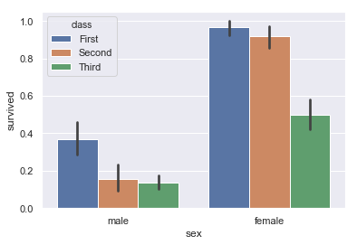

```python
sns.barplot(x='sex',y='survived',data=titanic,hue='class')
```

縦軸がデータの平均値、横軸がカテゴリーを表しています。

また黒い線はエラーバーといい、標準で95%信頼区間を表します。

この信頼区間の幅はciで変更できます。

# Countplot

こちらはデータの件数を集計したものを高さとして描画したものです。

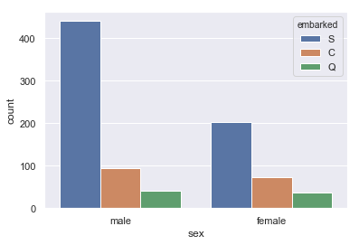

```python
sns.countplot(x='sex', hue='embarked', data=titanic)
```